# modelo

## Definir los acuíferos y sus propiedades

### Vamos a identificar los tres acuíferos prioritarios y sus propiedades:

Para crear un modelo de optimización en Python que considere la oferta, demanda, caudal del pozo, nivel de agua subterránea y los usos del pozo (doméstico, industrial, recreativo, comercial) para tres acuíferos en Panamá, sigue estos pasos:

1. Definir los acuíferos y sus propiedades
2. Identifica los tres acuíferos prioritarios y sus propiedades.

```python
import numpy as np
import pandas as pd
from scipy.optimize import minimize
import matplotlib.pyplot as plt
```

3. Definir la función objetivo y restricciones

La función objetivo funcion_objetivo busca minimizar el costo total de extracción de agua.

La función restricciones genera una lista de restricciones que limitan las cantidades de agua extraídas de acuerdo con los límites de extracción, recarga, caudales de los pozos y niveles de agua subterránea.

Estas funciones se utilizan típicamente en un contexto de optimización, donde se busca determinar la cantidad óptima de agua a extraer de cada fuente para minimizar costos mientras se cumplen todas las restricciones.

```python
def funcion_objetivo(x, demandas, costos):
    # Minimizar el costo del uso de agua
    return np.sum(x * costos)

def restricciones(limites, demandas, caudales, niveles):
    cons = []
    for i in range(len(demandas)):
        cons.append({'type': 'ineq', 'fun': lambda x, i=i: limites['extraccion'][i] - x[i]})
        cons.append({'type': 'ineq', 'fun': lambda x, i=i: x[i] - limites['recarga'][i]})
        cons.append({'type': 'ineq', 'fun': lambda x, i=i: caudales[i] - x[i]})  # Restricción de caudal del pozo
        cons.append({'type': 'ineq', 'fun': lambda x, i=i: niveles[i] - x[i]})   # Restricción del nivel de agua subterránea
    return cons
```

4. Configurar los datos

Configuramos los datos de oferta, demanda, límites de extracción y recarga, caudal y uso del pozo para los tres acuíferos en Panamá.

```python
# Datos de demanda y costos para cada acuífero
acuiferos = pd.DataFrame({
    'acuifero': ['A', 'B', 'C'],
    'demanda': [100, 150, 200],
    'costo': [1.5, 1.2, 1.8],
    'caudal': [110, 160, 210],
    'nivel_agua': [80, 120, 150],  # Nivel de agua subterránea en metros
    'uso': ['doméstico', 'industrial', 'recreativo']
})

# Límites de extracción y recarga para cada acuífero
limites = {
    'extraccion': [120, 180, 220],
    'recarga': [80, 140, 180]
}

# Valores iniciales para la optimización
x0 = [100, 150, 200]
```

5. Configurar y ejecutar el modelo de optimización

Usamos la función minimize de scipy.optimize para resolver el problema de optimización.

```python
constraints = restricciones(limites, acuiferos['demanda'], acuiferos['caudal'], acuiferos['nivel_agua'])
resultados = minimize(funcion_objetivo, x0, args=(acuiferos['demanda'], acuiferos['costo']), method='SLSQP', constraints=constraints, bounds=[(0, None)]*len(acuiferos))

# Mostrar los resultados
print("Resultados de optimización:")
print("Extracción óptima para cada acuífero:", resultados.x)
print("Valor de la función objetivo:", resultados.fun)
```

```
Resultados de optimización:
Extracción óptima para cada acuífero: [ 80. 140. 180.]
Valor de la función objetivo: 611.9999999997833
```

```python
escenarios = [
    {'nombre': 'Sin recursos adicionales', 'demanda': [100, 150, 200]},
    {'nombre': 'Con recursos adicionales', 'demanda': [120, 170, 220]}
]

for escenario in escenarios:
    acuiferos['demanda'] = escenario['demanda']
    resultado = minimize(funcion_objetivo, x0, args=(acuiferos['demanda'], acuiferos['costo']), method='SLSQP', constraints=restricciones(limites, acuiferos['demanda'], acuiferos['caudal'], acuiferos['nivel_agua']), bounds=[(0, None)]*len(acuiferos))
    print(f"Escenario: {escenario['nombre']}")
    print("Extracción óptima:", resultado.x)
    print("Valor de la función objetivo:", resultado.fun)
    print()
```

```
Escenario: Sin recursos adicionales
Extracción óptima: [ 80. 140. 180.]
Valor de la función objetivo: 611.9999999997833

Escenario: Con recursos adicionales
Extracción óptima: [ 80. 140. 180.]
Valor de la función objetivo: 611.9999999997833
```

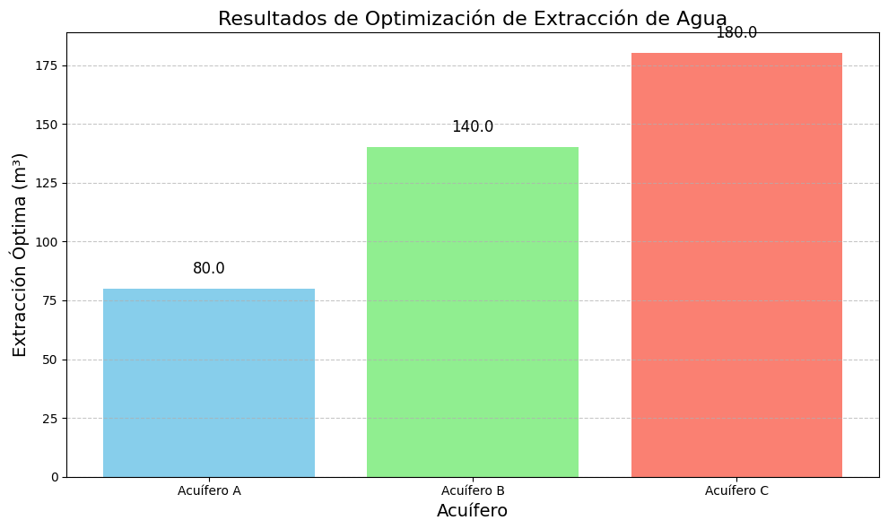

```python
# Crear figura y ejes
fig, ax = plt.subplots(figsize=(10, 6))

# Datos para el gráfico
acuiferos = ['Acuífero A', 'Acuífero B', 'Acuífero C']
extraccion_optima = resultados.x

# Crear gráfico de barras
bars = ax.bar(acuiferos, extraccion_optima, color=['skyblue', 'lightgreen', 'salmon'])

# Añadir etiquetas y título
ax.set_xlabel('Acuífero', fontsize=14)
ax.set_ylabel('Extracción Óptima (m³)', fontsize=14)
ax.set_title('Resultados de Optimización de Extracción de Agua', fontsize=16)
ax.grid(axis='y', linestyle='--', alpha=0.7)

# Añadir etiquetas de valor en las barras
for bar in bars:
    yval = bar.get_height()
    ax.text(bar.get_x() + bar.get_width() / 2, yval + 5, round(yval, 2), ha='center', va='bottom', fontsize=12)

# Mostrar el gráfico
plt.tight_layout()
plt.show()
```